# EDA with Linear Regression

# Introduction

Linear Regression algorithm is not just for predicting the future. It is actually super useful for gaining practically useful insights about the relationships among the variables in data. Thanks to its simplicity, we can even explain the insights from the model to other people in a human language, not necessarily in a mathematical or scientific language.

How do we use Linear Regression to find insights about the relationship among the variables in a typical exploratory data analysis?

# Data

Queried US Natality data from Google’s hosted public data repository at BigQuery. It is a data set about baby births in US.

```r
library(readr)
births <- read.csv("C:\\Users\\czwea\\Documents\\GitHub\\LargeDataFiles\\births.csv")
births <-select(births, -1)
df_status(births)
```

```r
births$mother_race <- mapvalues(births$mother_race, from = c(1, 2, 3, 4, 5, 6, 7), to = c("White", "Black", "American_Indian", "Chinese", "Japanese", "Hawaiian", "Filipino"))

births <- mutate(births, mother_race = case_when(mother_race == "68" ~ "Other_Asian",
                                                 mother_race =="18" ~ "Other_Asian",
                                                 mother_race =="78" ~ "Other_Asian",
                                                 mother_race =="48" ~ "Other_Asian",
                                                 mother_race =="28" ~ "Other_Asian",
                                                 mother_race =="38" ~ "Other_Asian",
                                                 mother_race =="58" ~ "Other_Asian",
                                                 TRUE ~ as.character(mother_race)))

births <- births %>% filter(!father_race == "99")

births$father_race <- mapvalues(births$father_race, from = c(1, 2, 3, 4, 5, 6, 7), to = c("White", "Black", "American_Indian", "Chinese", "Japanese", "Hawaiian", "Filipino"))

births <- mutate(births, father_race = case_when(father_race == "68" ~ "Other_Asian",
                                                 father_race =="18" ~ "Other_Asian",
                                                 father_race =="78" ~ "Other_Asian",
                                                 father_race =="48" ~ "Other_Asian",
                                                 father_race =="28" ~ "Other_Asian",
                                                 father_race =="38" ~ "Other_Asian",
                                                 father_race =="58" ~ "Other_Asian",
                                                 TRUE ~ as.character(father_race)))
```

## Explore Data

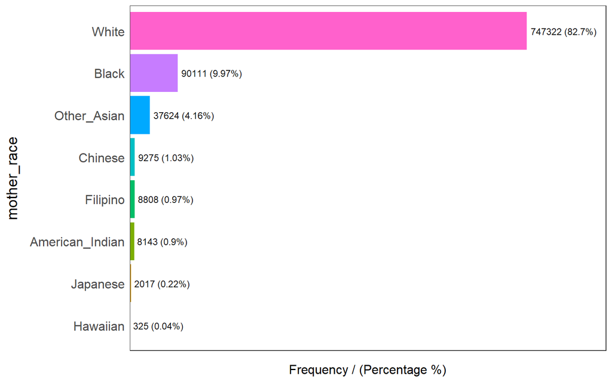

```
##       mother_race frequency percentage cumulative_perc
## 1           White    747322      82.70           82.70
## 2           Black     90111       9.97           92.67
## 3     Other_Asian     37624       4.16           96.83
## 4         Chinese      9275       1.03           97.86
## 5        Filipino      8808       0.97           98.83
## 6 American_Indian      8143       0.90           99.73
## 7        Japanese      2017       0.22           99.95
## 8        Hawaiian       325       0.04          100.00
```

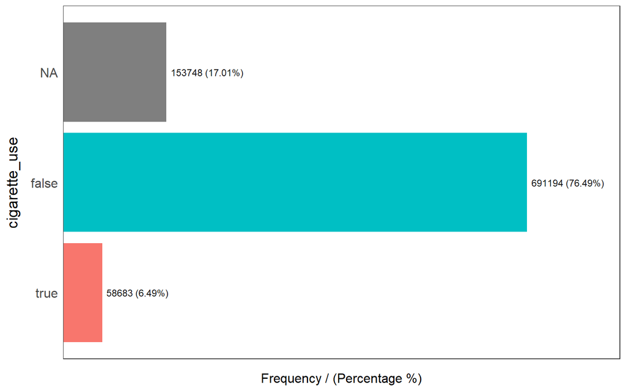

```
##   cigarette_use frequency percentage cumulative_perc
## 1         false    691194      76.49           76.49
## 2          <NA>    153748      17.01           93.50
## 3          true     58683       6.49          100.00
```

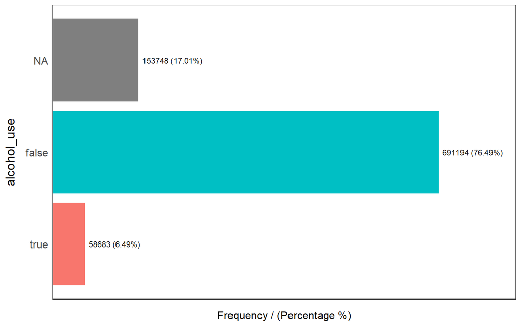

```
##   alcohol_use frequency percentage cumulative_perc
## 1       false    691194      76.49           76.49
## 2        <NA>    153748      17.01           93.50
## 3        true     58683       6.49          100.00
```

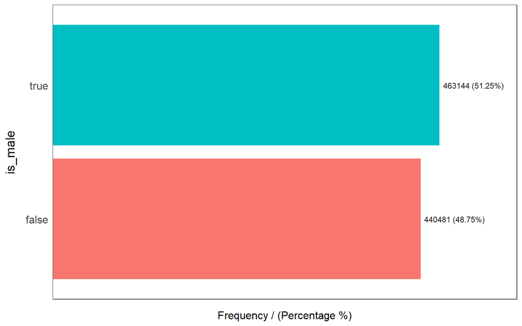

```
##   is_male frequency percentage cumulative_perc
## 1    true    463144      51.25           51.25
## 2   false    440481      48.75          100.00
```

```
## [1] "Variables processed: mother_race, cigarette_use, alcohol_use, is_male"
```

```r
freq(births, input = c("mother_race", "cigarette_use", "alcohol_use", "is_male"))
```

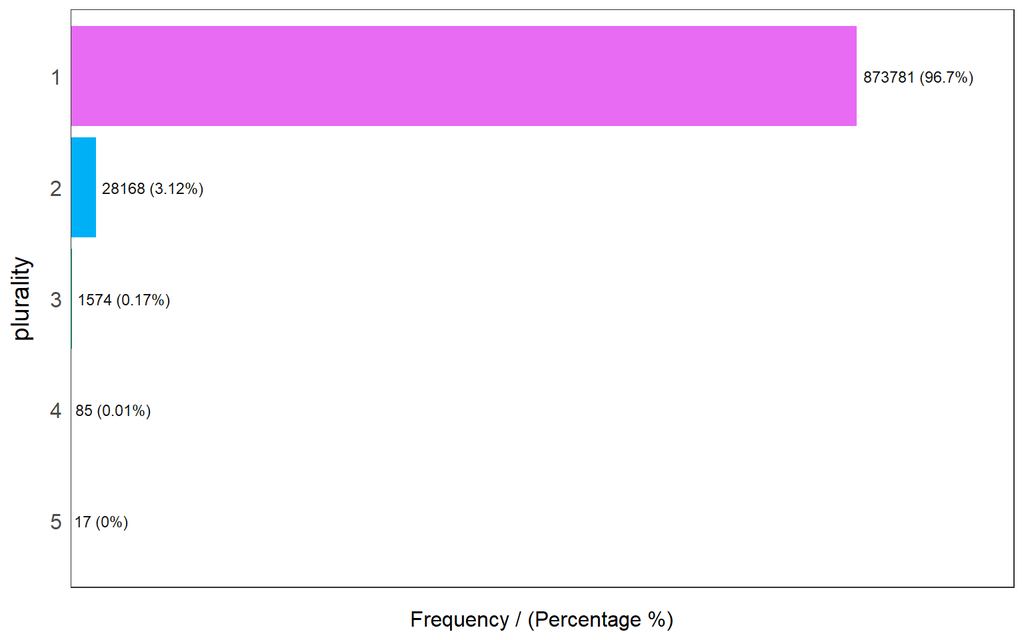

```
##   plurality frequency percentage cumulative_perc
## 1         1    873781      96.70           96.70
## 2         2     28168       3.12           99.82
## 3         3      1574       0.17           99.99
## 4         4        85       0.01          100.00
## 5         5        17       0.00          100.00
```

```r
freq(births, input = c("plurality"))
```

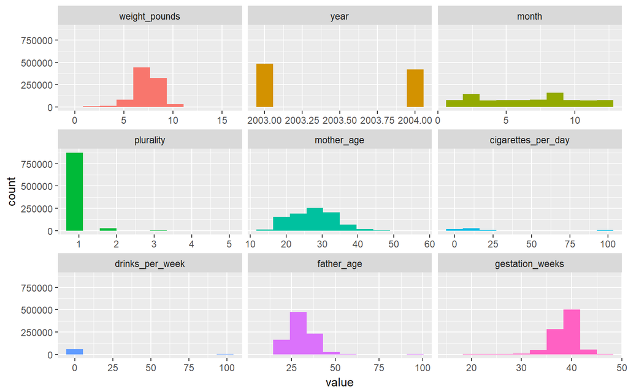

```r
plot_num(births)
```

```r
range(births$father_age)
```

```
## [1] 13 99
```

```r
#table(births$father_age)
nrow(filter(births, father_age ==99))
```

```
## [1] 3997
```

```r
births$father_age <- na_if(births$father_age, 99)
nrow(filter(births, father_age == 99))
```

```
## [1] 0
```

Explore the data by using charts to see if there are any trends that would help understand the relationship between `gestation_weeks` variable and the other variables.

```r
sum(is.na(births$gestation_weeks))
```

```
## [1] 0
```

```r
sum(is.na(births$father_age))
```

```
## [1] 3997
```

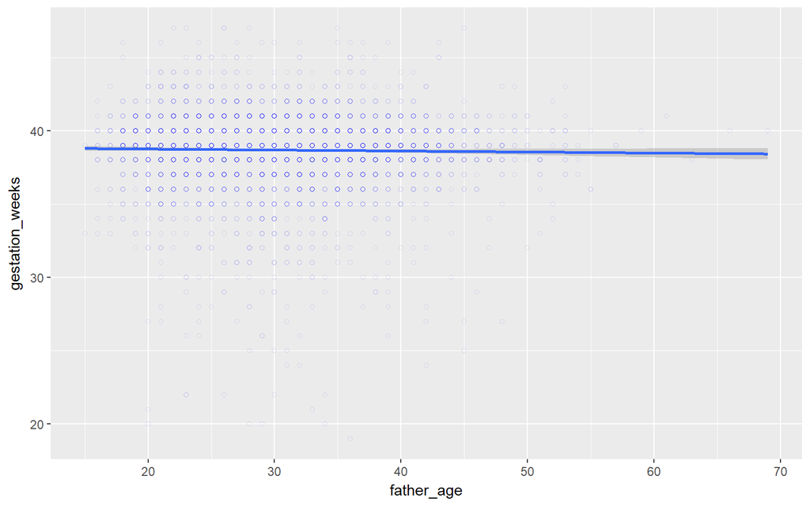

```r
tmpBirths <- births %>% filter(!is.na(father_age)) %>% sample_n(5000)
ggplot(tmpBirths, aes(x = father_age, y = gestation_weeks)) + geom_point(shape = 1, alpha = 0.1, color = "blue") +
     geom_smooth(method=lm)
```

We can’t really see an obvious correlation between the two variables. I’ve enabled a trend line (Linear Regression) inside the chart, and the line looks almost flat.

# Analysis

## father_age & father_race

```r
sum(is.na(tmpBirths$father_race))
```

```
## [1] 0
```

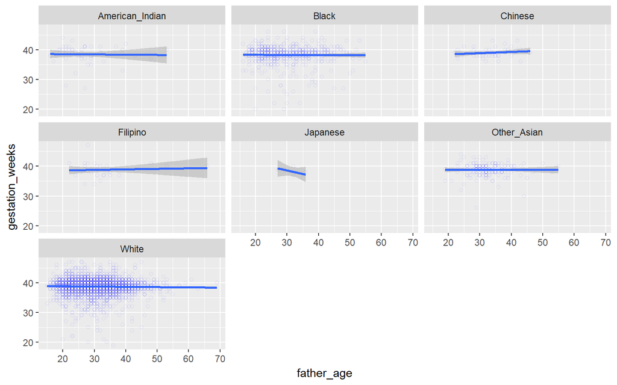

```r
tmpBirths <- tmpBirths %>% filter(!is.na(father_race))

ggplot(tmpBirths, aes(x = father_age, y = gestation_weeks)) + geom_point(shape = 1, alpha = 0.1, color = "blue") +
     geom_smooth(method=lm) + facet_wrap(~father_race)
```

## By mother_age

Here is the similar scatter chart we have already seen above. This time, I’m assigning `mother_age` to X-Axis.

```r
sum(is.na(tmpBirths$mother_age))
```

```
## [1] 0
```

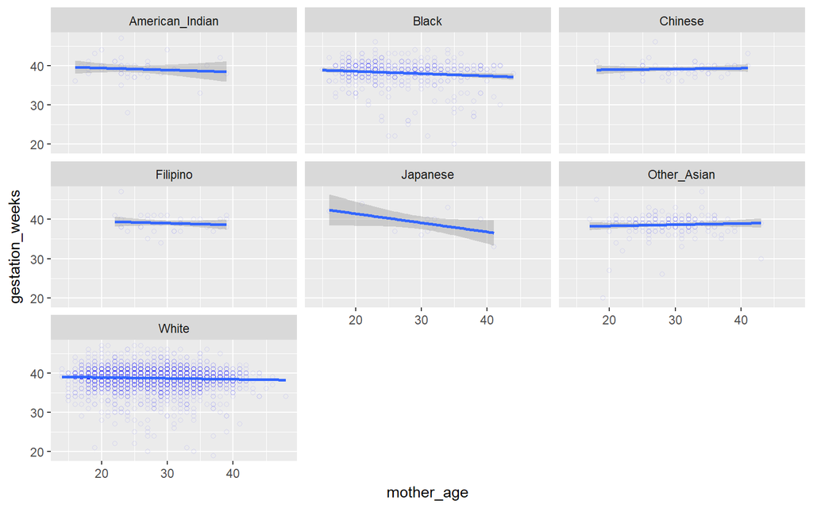

```r
ggplot(tmpBirths, aes(x = mother_age, y = gestation_weeks)) + geom_point(shape = 1, alpha = 0.1, color = "blue") +
     geom_smooth(method=lm) + facet_wrap(~mother_race)
```

It looks that there is a slight downward trend for a few races which means that as the mother’s age gets older the `gestation_weeks` becomes shorter.

## By `father_race`

How about the relationship between `father_race` and `gestation_weeks`. Here, I’m using a Bar chart to show the average `gestation_weeks` periods by each `father_race`. The red dotted line shows the overall average.

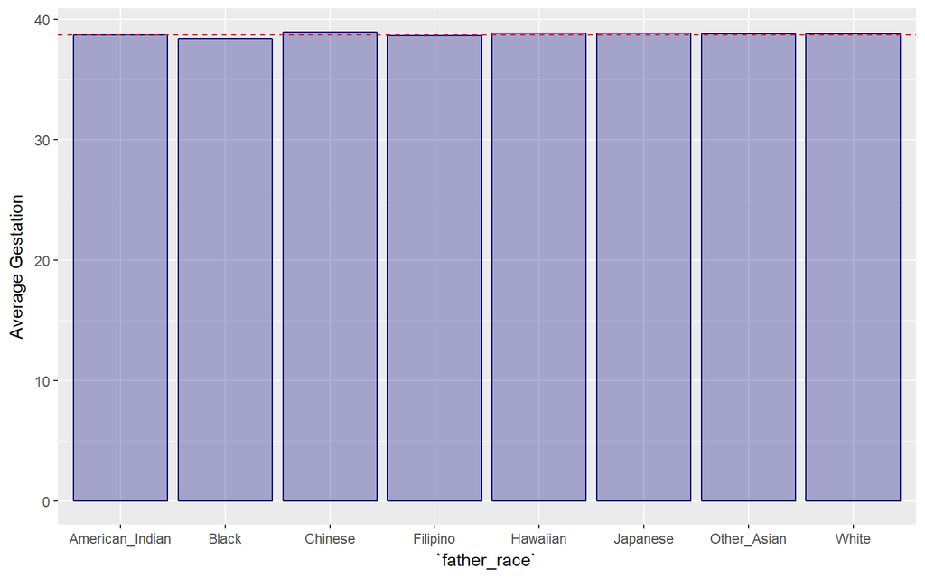

```r
fatherRace <- births %>% group_by(father_race) %>% summarise(meanGestation = mean(gestation_weeks))
ggplot(fatherRace, aes(as.factor(father_race), meanGestation)) +
     geom_bar(stat="identity", color = "navy", fill = "navy", alpha = .3) +
     labs(x="`father_race`", y = "Average Gestation") +
     geom_hline(yintercept = 38.69, linetype = "dashed", color = "red")
```

It’s hard to see the difference, so I’m zooming in to the area around the overall average age, which is 38.69.

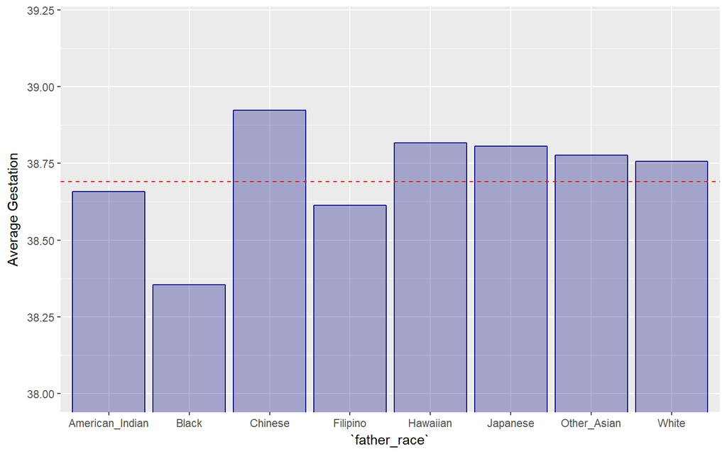

```r
ggplot(fatherRace, aes(as.factor(father_race), meanGestation)) +
     geom_bar(stat="identity", color = "navy", fill = "navy", alpha = .3) +
     labs(x="`father_race`", y = "Average Gestation") +
     coord_cartesian(ylim = c(38, 39.2)) +
     geom_hline(yintercept = 38.69, linetype = "dashed", color = "red")
```

Here, we can see some differences. Some races tend to have the `gestation_weeks` longer than the average. On the other hand, others tend to have the `gestation_weeks` shorter. However, we need to be reminded that the differences we are observing here are very small. They are all within less than a week.

## By `mother_race`

Let’s look at `nother_race` against `gestation_weeks` the same way we did for `father_race` above.

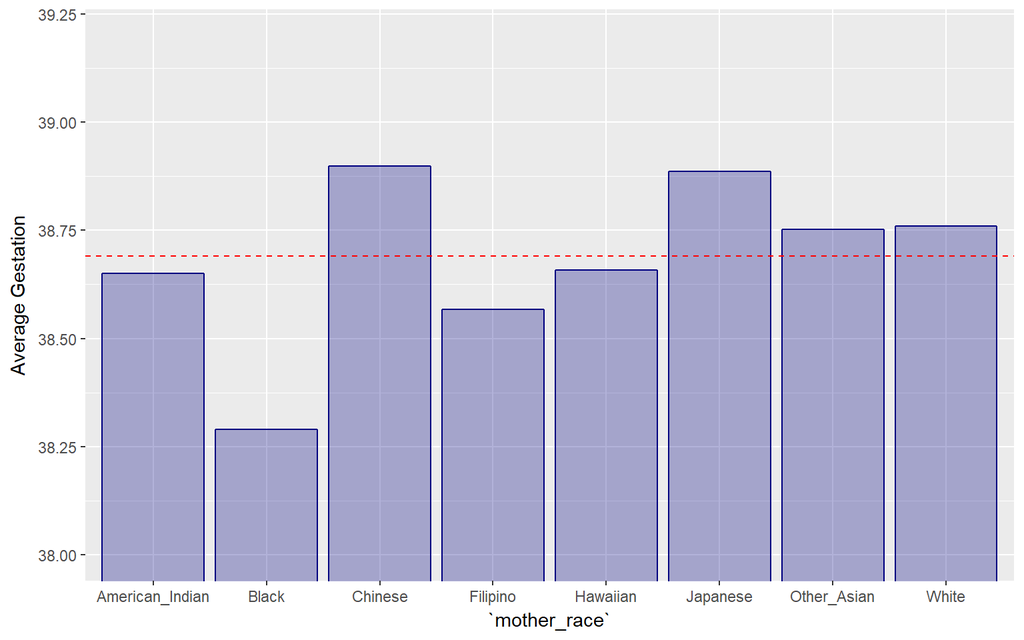

```r
motherRace <- births %>% group_by(mother_race) %>% summarise(meanGestation = mean(gestation_weeks))
ggplot(motherRace, aes(as.factor(mother_race), meanGestation)) +
     geom_bar(stat="identity", color = "navy", fill = "navy", alpha = .3) +
     labs(x="`mother_race`", y = "Average Gestation") +
     coord_cartesian(ylim = c(38, 39.2)) +
     geom_hline(yintercept = 38.69, linetype = "dashed", color = "red")
```

Simliar to `father_race`, some `mother_race` tend to be higher and lower than average. Blacks seem to be significantly lower.

## By Plurality

How about the relationship between `gestation_weeks` and `plurality`? Are twin or triplet (or even more!) babies are born earlier than single babies?

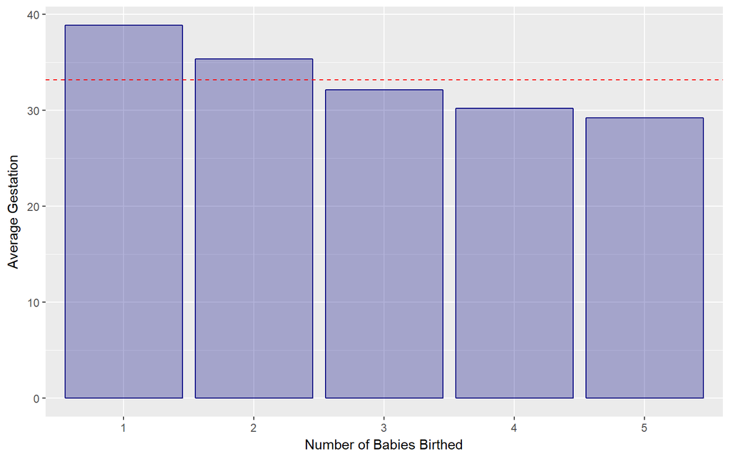

```r
gestation <- births %>% group_by(as.factor(plurality)) %>%
     summarise(meanGestation = mean(gestation_weeks))
names(gestation) <-  c("Plurality", "Average_Gestation")

ggplot(gestation, aes(Plurality, Average_Gestation)) +
     geom_bar(stat="identity", color = "navy", fill = "navy", alpha = .3) +
     labs(x="Number of Babies Birthed", y = "Average Gestation") +
     geom_hline(yintercept = mean(gestation$Average_Gestation), linetype = "dashed", color = "red")
```

This one is actually easier to spot the trend. As `plurality` increases the average of the `gestation_weeks` becomes shorter.

Instead of comparing the average of `gestation_weeks` by using Bar chart, we can see how the values of `gestation_weeks` are distributed or spread for each `plurality` number by using Boxplot chart like below.

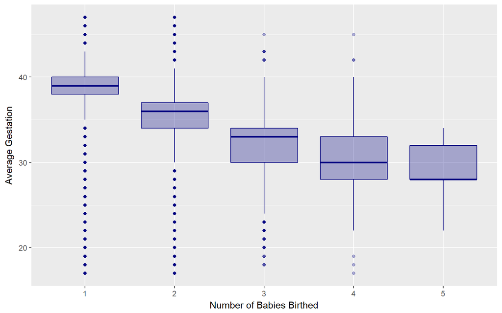

```r
ggplot(births, aes(as.factor(plurality), gestation_weeks)) +
     geom_boxplot(color = "navy", fill = "navy", alpha = .3, na.rm = TRUE) +
     labs(x="Number of Babies Birthed", y = "Average Gestation")
```

Y-Axis shows `gestation_weeks` and X-Axis shows `plurality`. Each box represents the range between 25 percentile and 75 percentile of `gestation+weeks` and the center line inside each box indicates the median value of `gestation_weeks`.

This Boxplot chart helps us to compare the distribution of `gestation_weeks` among `plurality` categories. We can see a trend that `gestation_weeks` values tend to go down as the number of `plurality` goes up, though there are some overlaps between them. This leads us to think that there seems to be a negative correlation between `gestation_weeks` and `plurality`.

I’ve got a few hypotheses based on the observations we have made so far.

- `father_age` and `mother_age` don’t seem to be making much difference for `gestation_weeks`, though they might be making a relatively bigger difference within some of the `father_race` or M`mother_race`.
- `father_race` and `mother_race` seem to be making differences, though the difference is very small, it’s less than a week, in terms of the average `gestation_weeks`.
- `plurality` seems to be making a big difference for `gestation_weeks`.

Now, let’s evaluate these hypotheses by building Linear Regression models.

## Linear Regression Model Evaluation

Let’s start evaluating the above hypotheses one by one by building Linear Regression models.

*Correlation is different from Causation.*

But there is one thing to note before moving further. By performing the regression analysis with Linear Regression algorithm we can understand the relationships between the variables better. And we might find that some of the variables might be able to explain a large portion of the changes in `gestation_weeks`.

But the relationships between the variables we are talking about here are **correlation**, which means that the changes in one variable can be observed at a same pace as the changes occur in another variable. Therefore, I might say something like “the changes in `father_age` would influence on the changes in `gestation_weeks`”, but this doesn’t necessarily mean that the changes in `father_age` are causing ’`gestation_weeks`’gestation_weeks` shorter or longer.

But, even if we don’t know if `father_age` is really causing the changes in `gestation_weeks`, just knowing that there is a correlation between them helps us predict or estimate how much `gestation_weeks` would change when we observe a certain amount of changes in `father_age`.

## gestation_weeks by father_age

```r
model_lm1 = lm(gestation_weeks ~ father_age, data = births)
summary(model_lm1)
```

```
##
## Call:
## lm(formula = gestation_weeks ~ father_age, data = births)
##
## Residuals:
##      Min       1Q   Median       3Q      Max
## -21.8145  -0.7503   0.2773   1.2864   8.5983
##
## Coefficients:
##               Estimate Std. Error t value Pr(>|t|)
## (Intercept) 38.9887162  0.0116349 3351.00   <2e-16 ***
## father_age  -0.0091717  0.0003768  -24.34   <2e-16 ***
## ---
## Signif. codes:  0 '***' 0.001 '**' 0.01 '*' 0.05 '.' 0.1 ' ' 1
##
## Residual standard error: 2.44 on 899626 degrees of freedom
##   (3997 observations deleted due to missingness)
## Multiple R-squared:  0.000658,   Adjusted R-squared:  0.0006569
## F-statistic: 592.3 on 1 and 899626 DF,  p-value: < 2.2e-16
```

**P-value** in this context is a probability of getting a similar set of changes even when there is no relationship between `father_age` and `gestation_weeks`. And if the probability is small enough (the very commonly known threshold is 5% but it can be higher or lower depending on the nature of the analysis.), then we would think that there has to be some degree of `father_age`’ influence on `gestation_weeks`.

Here, the P-value is a very small number. This means that if we assume that `father_age` doesn’t have any influence on the changes in `gestation_weeks`, the probability of getting a similar set of the changes in `gestation_weeks` is also very small. Therefore, we can practically conclude that this `father_age` has something to do with the changes in `gestation_weeks`.

The **coefficient estimate** here can be interpreted as, how much of the change in `gestation_weeks` can be explained (or influenced) by one value increase of `father_age`. The value here shows -0.009, which means that as the `father_age` becomes one year older the `gestation_weeks` would become 0.009 weeks shorter.

### Evaluate Quality of Prediction Model

To understand the quality of the model, there are many useful metrics, but here I want to introduce two practically useful ones.

**R Squared** measures how much of the variability of `gestation_weeks` this model can explain. The values vary between 0 and 1 in most cases and 1 is the highest, which means that the model can explain 100% of the variability of a target variable, in this case, that is `gestation_weeks`. The R Squared is 0.0007 means it doesn’t really explain the variability of `gestation_weeks`.

So, what is the variability anyway?

Use the same Scatter chart presented earlier to explain. It has been exploded to better serve as an explanatory example.

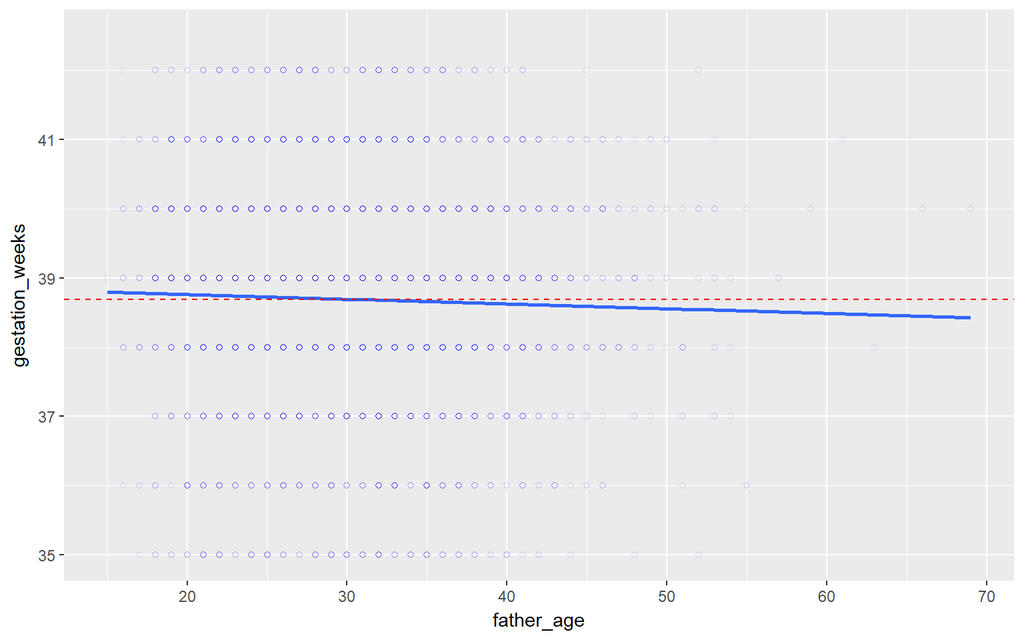

```r
ggplot(tmpBirths, aes(x = father_age, y = gestation_weeks)) +
     geom_point(shape = 1, alpha = 0.1, color = "blue") + geom_smooth(method=lm, se= FALSE) +
     geom_hline(yintercept = 38.69, linetype = "dashed", color = "red") +
     coord_cartesian(ylim = c(35, 42.5))
```

Here, I’m showing `father_age` at X-Axis and `gestation_weeks` at Y-Axis, and each dot represents each baby. Also, I’m showing a Trend Line (Linear Regression Model) as Blue Line to show the trend of the relationship between `father_age` and `gestation_weeks` as a straight line, and a Reference Line as Red Line to show the Average of `gestation_weeks`.

Now, as you recall, the R-Squared for this model is 0.0007.

Well, this 0.0007 actually is a byproduct of the difference between the Blue and the Red lines. Compared to the average reference line (Red), the trend line created by Linear Regression model (Blue) covers a bit more of the `gestation_weeks` spread. But, it still stays within a range of 38 and 39 of `gestation_weeks` and is not explaining the whole range of `gestation_weeks` (mainly from 25 to 45) very well.

**Is this model useless with such low R Squared?**

This doesn’t mean that the coefficient estimate of `father_age` is not reliable. Whether we can conclude if there is any meaningful linear relationship between `father_age` and `gestation_weeks` is entirely up to the P-value, which is another metric under the model summary.

Since we have only one predictor variable, this model level P-value happens to be the same value of P-value for `father_race` variable. But when we start adding more variables, this P-value of the model will be different from the P-value for the coefficient of each variable.

Nonetheless, P-value here is quite a small number so we can practically conclude that this prediction model built with `father_age` can explain the changes in `gestation_weeks`, even if the amount of the change it can explain is very tiny.

Another useful metric is **Root Mean Square Error (RMSE)**. This shows the average difference between the actual values and the values this model would predict — Predicted Values. Here, it is showing as about 2.4.

This means that if we used this model to predict the `gestation_weeks` it would make an error (difference) of 2.4 weeks on average.

**Summary**

> Given that one year increase in `father_age` would make `gestation_weeks` only 0.009 weeks shorter, 2.4 weeks error looks pretty big.

## mother_age

We have looked at the influence of `father_age` on `gestation_weeks`, but most of you must be thinking that actually `mother_age` should be the one having more influence on `gestation_weeks` than `father_age`.

I have switched from `father_age` to `mother_age` for the predictor variable and re-built the linear regression model.

```r
model_lm2 = lm(gestation_weeks ~ mother_age, data = births)
summary(model_lm2)
```

```
##
## Call:
## lm(formula = gestation_weeks ~ mother_age, data = births)
##
## Residuals:
##      Min       1Q   Median       3Q      Max
## -21.8588  -0.7659   0.2806   1.2961   8.5131
##
## Coefficients:
##               Estimate Std. Error t value Pr(>|t|)
## (Intercept) 39.1377985  0.0121490 3221.47   <2e-16 ***
## mother_age  -0.0154978  0.0004319  -35.88   <2e-16 ***
## ---
## Signif. codes:  0 '***' 0.001 '**' 0.01 '*' 0.05 '.' 0.1 ' ' 1
##
## Residual standard error: 2.442 on 903623 degrees of freedom
## Multiple R-squared:  0.001423,   Adjusted R-squared:  0.001422
## F-statistic:  1288 on 1 and 903623 DF,  p-value: < 2.2e-16
```

This time, the coefficient estimate of `mother_age` is -0.01, which means that one year increase of `mother_age` would make `gestation_weeks` 0.01 weeks shorter. It was -0.009 with `father_age`, so it seems to me that `mother_age` has more influencing power.

The R Squared is 0.001 and this is better than `father_age`.

The P-value is still nearly 0. This means, not only `mother_age` has something to do with the change in `gestation_weeks`.

Intuitively, we would think that older fathers tend to have babies with older mothers, and younger fathers tend to have babies with younger mothers. `father_age` and `mother_age` are probably positively correlated. And if that is the case, when we say `father_age` influences on `gestation_weeks` as we investigated above, in reality, that might be because `father_age` and `mother_age` happen to be correlated and `mother_age` could be actually the one that is impacting on `gestation_weeks`.

# Is `mother_age` Influencing or `father_age`?

So far, we know that the increases in `father_age` would make `gestation_weeks` shorter. And, the increases in `mother_age` would also make `gestation_weeks` shorter.

But wait for a second. . . aren’t younger mothers tend to have babies with younger fathers? And the same goes for older mothers, aren’t older mothers tend to have babies with older fathers? Aren’t `father_age` and `mother_age` in this data positively correlated?

Take a look at this Scatter chart that has `father_age` at X-Axis and `mother_age` at Y-Axis below.

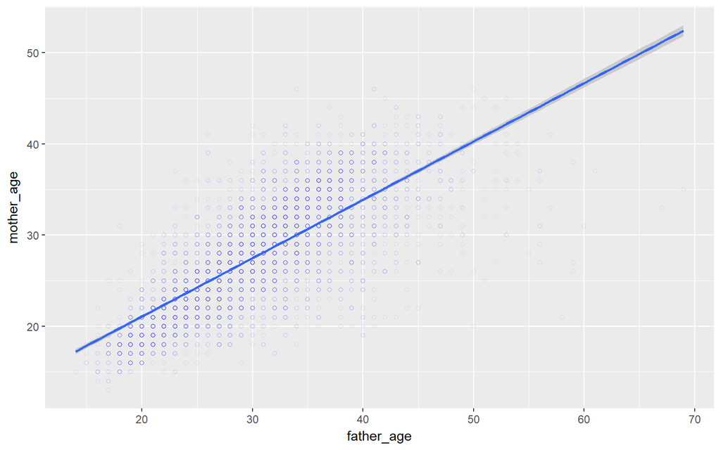

```r
tmpBirths <- births %>% filter(!is.na(father_age), mother_age) %>% sample_n(5000)
ggplot(tmpBirths, aes(x = father_age, y = mother_age)) +
     geom_point(shape = 1, alpha = 0.1, color = "blue") + geom_smooth(method=lm)
```

`father_age` and `mother_age` are positively correlated, which means that when `father_age` increases `mother_age` also increases.

By using Correlation analysis we can see that the correlation between them is 0.75, which means they are moderately positively correlated.

**Correlation = 0.75**

```r
set.seed(12345)
#Pearson
cor(tmpBirths$mother_age, tmpBirths$father_age, use = "complete.obs")
```

```
## [1] 0.7524232
```

`cor.test` provides the same information and more:

```r
cor.test(tmpBirths$mother_age, tmpBirths$father_age)#gets the p value
```

```
##
##  Pearson's product-moment correlation
##
## data:  tmpBirths$mother_age and tmpBirths$father_age
## t = 80.758, df = 4998, p-value < 2.2e-16
## alternative hypothesis: true correlation is not equal to 0
## 95 percent confidence interval:
##  0.7401407 0.7642037
## sample estimates:
##       cor
## 0.7524232
```

```r
tmpBirths_1 <- tmpBirths %>% select(mother_age, father_age) %>% tidyr::drop_na()
correlation_table(tmpBirths_1, "mother_age")
```

```
##     Variable mother_age
## 1 mother_age       1.00
## 2 father_age       0.75
```

This code is interesting - it performs a pairwise correlation but must manage the missing data to return the same data as the methods above!

```r
library("PerformanceAnalytics")
```

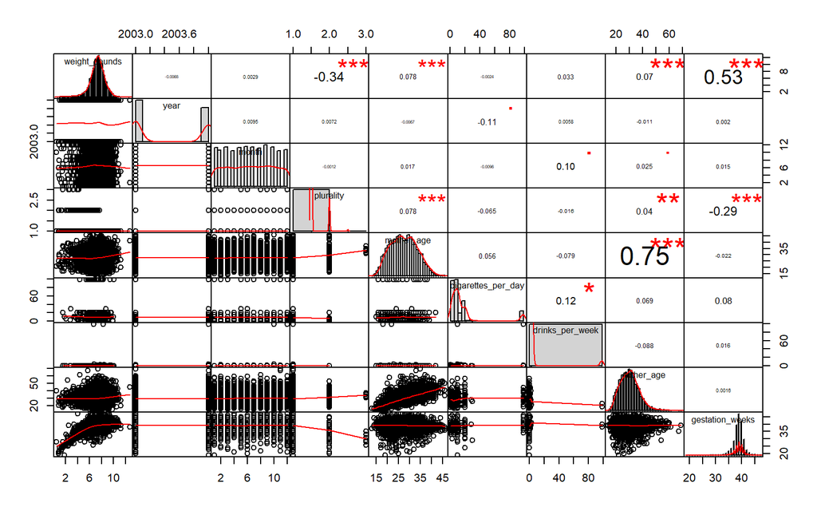

```r
chart.Correlation(select_if(tmpBirths, is.numeric), histogram = TRUE, pch = 19)
```

```r
#Pairwise Coefficients
cor(select_if(tmpBirths, is.numeric), use = "complete.obs")
```

```
##                    weight_pounds         year        month    plurality
## weight_pounds        1.000000000 -0.114098527 -0.012041008 -0.297105029
## year                -0.114098527  1.000000000  0.039707898  0.043879049
## month               -0.012041008  0.039707898  1.000000000  0.129799317
## plurality           -0.297105029  0.043879049  0.129799317  1.000000000
## mother_age           0.097454286 -0.068886860  0.122857614  0.050654161
## cigarettes_per_day  -0.002382017 -0.108295152 -0.007617258 -0.064937408
## drinks_per_week      0.032645506  0.006079754  0.102987035 -0.016154394
## father_age           0.092143931 -0.136828290  0.110217487  0.009838838
## gestation_weeks      0.574961456 -0.051947995 -0.002745579 -0.211722500
##                     mother_age cigarettes_per_day drinks_per_week
## weight_pounds       0.09745429       -0.002382017     0.032645506
## year               -0.06888686       -0.108295152     0.006079754
## month               0.12285761       -0.007617258     0.102987035
## plurality           0.05065416       -0.064937408    -0.016154394
## mother_age          1.00000000        0.056268010    -0.078798505
## cigarettes_per_day  0.05626801        1.000000000     0.120213785
## drinks_per_week    -0.07879851        0.120213785     1.000000000
## father_age          0.69111594        0.067567798    -0.088547258
## gestation_weeks    -0.05360928        0.078542010     0.015555514
##                      father_age gestation_weeks
## weight_pounds       0.092143931     0.574961456
## year               -0.136828290    -0.051947995
## month               0.110217487    -0.002745579
## plurality           0.009838838    -0.211722500
## mother_age          0.691115943    -0.053609283
## cigarettes_per_day  0.067567798     0.078542010
## drinks_per_week    -0.088547258     0.015555514
## father_age          1.000000000     0.001543791
## gestation_weeks     0.001543791     1.000000000
```

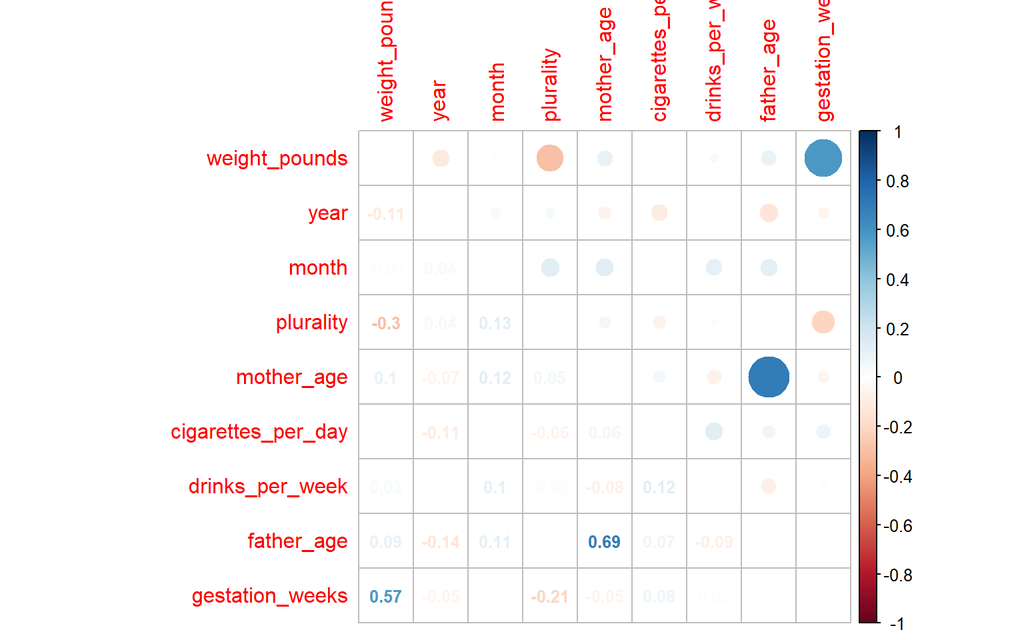

```r
myCOR <- cor(select_if(tmpBirths, is.numeric), use = "complete.obs")
corrplot.mixed(myCOR, number.cex = .8, tl.pos = "lt")
```

**Is `father_age` alone really influencing the changes?**

Assume: An older father had a baby recently, and the baby came out earlier than the average (Shorter `gestation_weeks`). Now, is this because the father is older? Or, maybe his wife or partner happened to be also older and could that be actually the direct influence of having the baby earlier than the average?

So instead of `father_age` directly influencing `gestation_weeks`, maybe `father_age` is influencing `mother_age` to be younger or older, and then `mother_age` ends up directly influencing `gestation_weeks` to be shorter or longer.

To answer this question we can bring `father_age` and `mother_age` together as the predictor variables and re-build the regression model.

When we have multiple predictor variables we can interpret each coefficient of the variables as *one point increase in a given predictor variable would increase or decrease a certain amount in the target variable when values in other variables stay the same*.

It means that we can say if one year increase in `father_age` would increase or decrease some amount of `gestation_weeks` when `mother_age` stays the same. We can separate the potential influence of `mother_age` from the influence of `father_age`. This goes the other way around, too. We can evaluate the `mother_age`’s influence alone without a potential influence of `father_age` by having these two variables as predictors.

## `father_age` and `mother_age`

Rebuild the Linear Regression model.

```r
set.seed(1)
model_lm3 <- lm(gestation_weeks ~ mother_age + father_age, data = tmpBirths)
summary(model_lm3)
```

```
##
## Call:
## lm(formula = gestation_weeks ~ mother_age + father_age, data = tmpBirths)
##
## Residuals:
##      Min       1Q   Median       3Q      Max
## -19.8082  -0.7709   0.2591   1.2741   8.3937
##
## Coefficients:
##              Estimate Std. Error t value Pr(>|t|)
## (Intercept) 38.905707   0.171770 226.499   <2e-16 ***
## mother_age  -0.022405   0.008917  -2.513   0.0120 *
## father_age   0.014918   0.007585   1.967   0.0493 *
## ---
## Signif. codes:  0 '***' 0.001 '**' 0.01 '*' 0.05 '.' 0.1 ' ' 1
##
## Residual standard error: 2.463 on 4997 degrees of freedom
## Multiple R-squared:  0.001264,   Adjusted R-squared:  0.0008646
## F-statistic: 3.163 on 2 and 4997 DF,  p-value: 0.04238
```

The P-value for `father_age` variable has increased a lot and came to a point where we are not so sure if we should be confident that `father_age` is really influencing on `gestation_weeks` when `mother_age` stay the same.

Let’s take a look at `mother_age` variable. Its P-value is much smaller compared to the one for `father_age`.

So the probability of getting the similar changes in `gestation_weeks` without any influence of `mother_age` when `father_age` stays the same is very low. So if anything, `mother_age` can be more reliable to explain the changes in `gestation_weeks` than `father_age`. And this means that we can interpret that `mother_age` is probably the one that is more of a direct influence on `gestation_weeks`. And the reason `father_age` looked influencing on `gestation_weeks` in the previous analysis could be because it happened to be correlated well with `mother_age`.

The coefficient estimate of `mother_age` is -0.02, which means that one year increase in `mother_age` would make `gestation_weeks` 0.02 weeks shorter when `father_age` stays the same.

## Is `father_age` a Fake Variable?

Now that we are finding that `mother_age` is most likely the one influencing the changes in `gestation_weeks` more than `father_age`, does this mean that `father_age` doesn’t have any influence at all on `gestation_weeks`?

To answer this question, we can take a look at the model summary:

```r
summary(model_lm3)
```

```
##
## Call:
## lm(formula = gestation_weeks ~ mother_age + father_age, data = tmpBirths)
##
## Residuals:
##      Min       1Q   Median       3Q      Max
## -19.8082  -0.7709   0.2591   1.2741   8.3937
##
## Coefficients:
##              Estimate Std. Error t value Pr(>|t|)
## (Intercept) 38.905707   0.171770 226.499   <2e-16 ***
## mother_age  -0.022405   0.008917  -2.513   0.0120 *
## father_age   0.014918   0.007585   1.967   0.0493 *
## ---
## Signif. codes:  0 '***' 0.001 '**' 0.01 '*' 0.05 '.' 0.1 ' ' 1
##
## Residual standard error: 2.463 on 4997 degrees of freedom
## Multiple R-squared:  0.001264,   Adjusted R-squared:  0.0008646
## F-statistic: 3.163 on 2 and 4997 DF,  p-value: 0.04238
```

R Squared almost always goes up when you add more variables regardless whether they can really explain the changes in the target variable or not. To address this problem, we have a variation of R Squared called Adjusted R Squared, which penalizes for adding more variables, therefore, it can go down when you add variables that don’t contribute in explaining the variability of the target variable.

# Categorical Predictors

But, how about categorical variables like `mother_race` whose values can be White, Black, Japanese, etc. What does it mean when we say “one point increase in `father_race` would increase or decrease `gestation_weeks` for some amounts?”

Before getting into the details, let’s first build a regression model by assigning only `mother_race` as the predictor variable.

```r
model_lm4 <- lm(gestation_weeks ~ factor(mother_race), data = births)
summary(model_lm4)
```

```
##
## Call:
## lm(formula = gestation_weeks ~ factor(mother_race), data = births)
##
## Residuals:
##      Min       1Q   Median       3Q      Max
## -21.7601  -0.7601   0.2399   1.2399   8.7099
##
## Coefficients:
##                                 Estimate Std. Error  t value Pr(>|t|)
## (Intercept)                    38.650620   0.027033 1429.761  < 2e-16 ***
## factor(mother_race)Black       -0.360556   0.028228  -12.773  < 2e-16 ***
## factor(mother_race)Chinese      0.246954   0.037045    6.666 2.63e-11 ***
## factor(mother_race)Filipino    -0.082954   0.037502   -2.212 0.026966 *
## factor(mother_race)Hawaiian     0.007841   0.137988    0.057 0.954683
## factor(mother_race)Japanese     0.235845   0.060672    3.887 0.000101 ***
## factor(mother_race)Other_Asian  0.101878   0.029815    3.417 0.000633 ***
## factor(mother_race)White        0.109456   0.027180    4.027 5.65e-05 ***
## ---
## Signif. codes:  0 '***' 0.001 '**' 0.01 '*' 0.05 '.' 0.1 ' ' 1
##
## Residual standard error: 2.439 on 903617 degrees of freedom
## Multiple R-squared:  0.003415,   Adjusted R-squared:  0.003408
## F-statistic: 442.4 on 7 and 903617 DF,  p-value: < 2.2e-16
```

Linear Regression function ‘lm’ in R automatically transforms a categorical variable into something called ‘dummy’ variables. It will create a column for each categorical value (e.g. Japanese) and have a value of 0 or 1 based on whether a given row matches a given column (e.g. Japanese or not).

Each of the dummy columns represents each `mother_race` type, except for one `mother_race` type, in this case, that is American Indian, which happens to be the base level of `mother_race` column. **How has the base level been decided**?

If a predictor variable is `haracter data type, then R’s lm function automatically picks the first unique value in an alphabetical order and set it to the base level. And, ‘American Indian` happens to be the first value. This concept of the base level becomes very important when we try to understand the coefficients for the categorical variables.

We can see `mother_race — Black` P-value is very small. And we can interpret it as, *One value increase of `mother_race — Black` would decrease about 0.36 weeks in `gestation_weeks` when all the other variables stay the same.* The last part is technically saying that all the other dummy variables are zero.

## Changing Base Level

We know how to interpret the coefficient for the categorical variables. But, when we say that `mother_race — Black` would make the `gestation_weeks` 0.36 weeks shorter compared to American Indian, it is not necessarily straightforward to understand for many unless you happen to be an `American Indian` or be familiar with American Indian sociology. The problem is that unless we are very familiar with the base level value (e.g. `American Indian`) we don’t know what to do with such insights.

It would be easier to interpret the coefficient if we can change the base level to be something we are more familiar with. For example, if you happen to be a `Japanese`, then you might want to compare Black Mother to Japanese Mother. Or, you might want to compare any Race to the majority race like `White` in the data set.

A package called `forcats` from Hadley Wickham — a father of the modern R — provides a set of convenient functions to work with Factor data type. Use `fct_relevel` function to set the base level quickly.

```r
births$mother_race <- forcats::fct_relevel(births$mother_race, "White")
```

Now that `mother_race` is Factor type and its base level is `White`, we can re-build the model with the same configuration. Note that you need to make sure you have removed the filter that kept only American Indian and Black if you have created the filter before.

```r
model_lm4_2 <- lm(gestation_weeks ~ factor(mother_race), data = births)
summary(model_lm4_2)
```

```
##
## Call:
## lm(formula = gestation_weeks ~ factor(mother_race), data = births)
##
## Residuals:
##      Min       1Q   Median       3Q      Max
## -21.7601  -0.7601   0.2399   1.2399   8.7099
##
## Coefficients:
##                                     Estimate Std. Error   t value Pr(>|t|)
## (Intercept)                        38.760077   0.002822 13735.782  < 2e-16
## factor(mother_race)American_Indian -0.109456   0.027180    -4.027 5.65e-05
## factor(mother_race)Black           -0.470012   0.008602   -54.638  < 2e-16
## factor(mother_race)Chinese          0.137497   0.025486     5.395 6.86e-08
## factor(mother_race)Filipino        -0.192411   0.026145    -7.359 1.85e-13
## factor(mother_race)Hawaiian        -0.101615   0.135344    -0.751   0.4528
## factor(mother_race)Japanese         0.126388   0.054390     2.324   0.0201
## factor(mother_race)Other_Asian     -0.007578   0.012889    -0.588   0.5566
##
## (Intercept)                        ***
## factor(mother_race)American_Indian ***
## factor(mother_race)Black           ***
## factor(mother_race)Chinese         ***
## factor(mother_race)Filipino        ***
## factor(mother_race)Hawaiian
## factor(mother_race)Japanese        *
## factor(mother_race)Other_Asian
## ---
## Signif. codes:  0 '***' 0.001 '**' 0.01 '*' 0.05 '.' 0.1 ' ' 1
##
## Residual standard error: 2.439 on 903617 degrees of freedom
## Multiple R-squared:  0.003415,   Adjusted R-squared:  0.003408
## F-statistic: 442.4 on 7 and 903617 DF,  p-value: < 2.2e-16
```

And here again, `mother_race` — Black is the most statistically significant. And we can interpret it as, Black Mother tends to have `gestation_weeks` 0.47 weeks shorter compared to White Mother.

## Categorical Variables Can Be Correlated Too!

### Father and Mother Race

Just as we have investigated the relationship of `father_Age` and `mother_age` earlier, we would intuitively think that `father_race` and `mother_race` are also *correlated*, meaning that White mothers tend to have babies with White fathers, Black mothers tend to have babies with Black fathers, and so on.

Here is a chart that shows the ratio of the mothers in each race married to each `father_race` type.

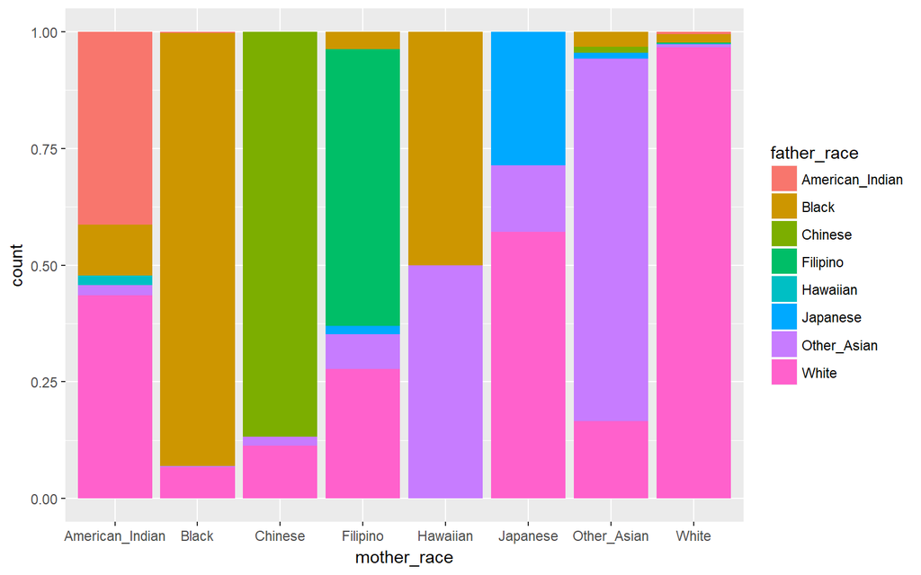

```r
ggplot(tmpBirths, aes(x = mother_race, fill = father_race)) + geom_bar(position = "fill")
```

A majority of the mothers in most races had their babies with the fathers of their race.

The important point is `mother_race` and `father_race` seem to be correlated. If we know a given baby’s `mother_race`, then we can predict what her/his `father_race` is with a good accuracy rate for some of the races.

So again, we don’t know if `mother_race` is really the one influencing the changes in `gestation_weeks`. Maybe `mother_race` being Black means most likely `father_race` is also Black and that might be directly making the `gestation_weeks` shorter.

To find this out, again, we can turn to the same Linear Regression algorithm.

We can include both `mother_race` and `father_race` as the predictors and re-build the model. This will allow us to see the true impact of each `mother_race` type.

```r
model_lm5 <- lm(gestation_weeks ~ mother_race + father_race, data = births)
summary(model_lm5)
```

```
##
## Call:
## lm(formula = gestation_weeks ~ mother_race + father_race, data = births)
##
## Residuals:
##      Min       1Q   Median       3Q      Max
## -21.7694  -0.7616   0.2384   1.2384   8.7157
##
## Coefficients:
##                             Estimate Std. Error  t value Pr(>|t|)
## (Intercept)                38.709772   0.031882 1214.145  < 2e-16 ***
## mother_raceAmerican_Indian -0.080051   0.032144   -2.490 0.012760 *
## mother_raceBlack           -0.395125   0.016777  -23.552  < 2e-16 ***
## mother_raceChinese          0.006844   0.045218    0.151 0.879689
## mother_raceFilipino        -0.200947   0.034852   -5.766 8.13e-09 ***
## mother_raceHawaiian        -0.121450   0.136824   -0.888 0.374738
## mother_raceJapanese         0.111852   0.061141    1.829 0.067338 .
## mother_raceOther_Asian     -0.076546   0.022405   -3.416 0.000634 ***
## father_raceBlack           -0.030349   0.035089   -0.865 0.387093
## father_raceChinese          0.213318   0.057245    3.726 0.000194 ***
## father_raceFilipino         0.059426   0.050280    1.182 0.237246
## father_raceHawaiian         0.156184   0.141120    1.107 0.268403
## father_raceJapanese         0.056052   0.079361    0.706 0.480004
## father_raceOther_Asian      0.136210   0.038967    3.496 0.000473 ***
## father_raceWhite            0.051793   0.031924    1.622 0.104726
## ---
## Signif. codes:  0 '***' 0.001 '**' 0.01 '*' 0.05 '.' 0.1 ' ' 1
##
## Residual standard error: 2.439 on 903610 degrees of freedom
## Multiple R-squared:  0.003476,   Adjusted R-squared:  0.00346
## F-statistic: 225.1 on 14 and 903610 DF,  p-value: < 2.2e-16
```

Now we can see that if `mother_race` is Black the `gestation_weeks` would become 0.39 weeks shorter compared to when `mother_race` is White assuming that `father_race` stays the same.

Also, we can notice that the coefficient of `father_race` being Black is not statistically significant.

We can practically conclude that it is `Mother Race` that would more directly influence the changes in `Gestation Week` than `Father Race`.

Based on the findings so far, we know that `mother_age` and `mother_race` tend to have a reasonable amount of influence on the changes in `gestation_weeks`.

Now, as you might be wondering, the obvious question is, which of `mother_age` and `mother_race` is more directly influencing the changes in `gestation_weeks`? Maybe some of the `mother_race`s tend to be older than the others. If that’s the case `mother_race` might be carrying over the influence of `mother_age`.

https://www.r-bloggers.com/analysis-of-covariance-–-extending-simple-linear-regression/